# Introduction to Reinforcement Learning

### London Self-Driving/Autonomous Car Technology Meetup

Sander van Dijk @ Parkopedia

27 February 2017

# Horrible Histories

## Reinforcing Rats

# Horrible Histories

## Rodent Junkies and Self-Pleasuring

# Learning Problems

- **Supervised Learning** - *Learn from labelled examples*  
  Image classification, parking availability prediction, behaviour cloning, ...
- **Unsupervised Learning** - *Find new structure in unlabelled data*  
  Clustering, anomaly detection, self-organising maps, ...
- **Reinforcement Learning** - *Learn from sparse, delayed reward*  
  Lever pressing, football, video games, ...

[figure not shown]

# Formally: Markov Decision Process

- **State** of environment  
  $s$, $s'$
- **Action** chosen by agent  
  $a$, $a'$
- **Transition** model: how actions transform state  
  $T_{s, a}^{s'} = Pr(s'|s, a)$
- Agent's **policy**: how agent choses actions  
  $\pi(s, a) = Pr(a|s)$
- **Reward** function  
  $r_{s,a}^{s'} = R(s, a, s')$

# Goal: Maximise Expected Reward!

How much reward will the agent likely get from now until end of time?

Total reward of one episode:

$ R^\infty = r_1 + r_2 + r_3 + \ldots + r_\infty $

*Value function* - total expected reward:

$ V(s) = E[R^\infty | s] \\ ~ \\ ~ = \sum_a \pi(s, a) \sum_{s'} [ T_{s, a}^{s'} \cdot r_{s,a}^{s'} + \sum_{a'} \ldots \\ ~ \\ ~ = \sum_a \pi(s, a) \sum_{s'} [ T_{s, a}^{s'} \cdot r_{s,a}^{s'} + V(s') ]$

To find the optimal states to be in, the agent is interested in the optimal value function:

$V^*(s) = max_a \sum_{s'} [ T_{s, a}^{s'} \cdot r_{s,a}^{s'} + V^*(s') ]$

# Solution: Value Iteration

1. Start with random estimate of value function, $V_0(s)$
2. Iterate until convergence

$V_{k+1}(s) = max_a \sum_{s'} [ T_{s, a}^{s'} \cdot r_{s,a}^{s'} + V_k(s') ]$

# Example: Coco's Pizza Hunt

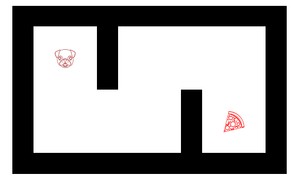

```python
world = coco_world()
draw_world(world, coco_pos=(2, 2), goal_pos=(5, 10))
```

# Example: Value Iteration

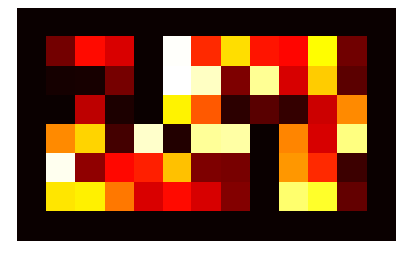

```python
transition_model = create_transition_model(world)
reward_function = create_reward_function(world, goal_pos=(5, 10))
value_function = create_random_value_function(world)
draw_value_function(world, value_function)
```

# Optimal Policy

Once optimal value function is found, finding optimal policy is trivial:

$ \pi^*(s, a) = 1 : a = \underset{a}{\operatorname{argmax}} \sum_{s'} [ T_{s, a}^{s'} \cdot r_{s,a}^{s'} + V^*(s') ] $

*Pick action leading to maximum value*

# Solved! Or..?

- Infinite sum of reward - 'discount' factor $0 \le \gamma \le 1$ tradiing off long term and short term reward

  $ \sum_a \pi(s, a) \sum_{s'} [ T_{s, a}^{s'} \cdot r_{s,a}^{s'} + \color{red}{\gamma} V(s') ]$
- Reward function design - narrow sighted greed, unwanted effects
- **This is not Reinforcement Learning!**

# Real Reinforcement Learning

Coco knows too much!

- Do you always know the consequences of your actions? $T_{s,a}^{s'}$ unknown!
- What are the good outcomes? $R(s, a, s')$ unknown

Options:

1. Learn models from experience at the same time
2. Model free learning

# Temporal Difference (TD) Learning: No More Models

Idea: a single time step already gives some information about value.

1. Start with random value function and some policy
2. Observe current state $s$
3. Perform action $a$ based on policy
4. Observe new state $s$ and immediate reward $r$
5. Update value of previous state: $V(s) \leftarrow V(s) + \alpha [r + \gamma V(s') - V(s)]$
6. Goto 2

Problem: learns value of current policy, not optimal policy; '*On-Policy*'

# Q-Learning: Off-Policy Learning

Idea: assign value to state-action pair: $Q(s, a)$

1. Start with random Q-value function
2. Observe current state $s$
3. Perform action $a$ based on policy *derived from Q*
4. Observe new state $s$ and immediate reward $r$
5. Update value of previous state-action: $Q(s, a) \leftarrow Q(s, a) + \alpha [r + \gamma \max_a' Q(s', a') - Q(s, a)]$
6. Goto 2

Can learn optimal value + policy, even when just acting randomly!

# State of the Art RL! ... in 1989

Can't really deal with:

- Huge spaces (camera feed, Atari screen, Go board, ...)
- Continuous spaces (steering angles, joint motor angles, ...)

Needed: *Function approximation*:

- Learn parameters $\theta$ of some function $f_\theta(s, a)$ to approximate $Q(s,a)$
- Linear regression, (deep) neural network, ...

# Continuous actions

So, function approximation! But...

- Not guaranteed to converge (but let's forget about that for now...)
- Find best action? Search action space? Evaluate $Q(s,a)$ many times..

Split learner into two parts:

1. Critic - learns value function
2. Actor - learns best actions

# Actor-Critic Methods

[figure not shown]

# Deep Q Learning

[figure not shown]

- DeepMind - [Nature, February 2015](http://www.nature.com/nature/journal/v518/n7540/full/nature14236.html)
- Learned to play Atari games purely from pixel input
- Use CNN to learn Q-value
- Limited amount of discreet actions

# Catastrophic Forgetting

Learning in one area can undo learning in another. Stability trick: *experience replay*

[figure not shown]

# Learning to Drive?

DeepMind - [ICLR 2016](https://arxiv.org/abs/1509.02971), Deep Actor-Critic Method

[figure not shown]

# Simulation is Cool, but...

Results difficult to transfer to real world:

- Use racing game policy in the City?
- Simulation never perfect: overfitting
- 'Crash into wall' reinforcement not useful in real car
- Tesla, Uber, Nvidia, Google are on it!

[figure not shown]

# Making it more Human: Hierarchy

# Making it more Human: Back to Models

[figure not shown]

[Cambridge + Google Brain + DeepMind, 2016](https://arxiv.org/pdf/1603.00748.pdf)

# Resources

- ['The Book'](https://webdocs.cs.ualberta.ca/~sutton/book/the-book.html) - Reinforcement Learning, Sutton & Barto
- [Demystifying Deep Reinforcement Learning](https://www.nervanasys.com/demystifying-deep-reinforcement-learning/)
- [Berkeley Deep RL Course](http://rll.berkeley.edu/deeprlcourse/)
- [Reinforcement Learning: Top 10 Breakthrough Technologies](https://www.technologyreview.com/s/603501/10-breakthrough-technologies-2017-reinforcement-learning/) - As judged by MIT Technology Review

# Deep Q-Network

[figure not shown]

# Stability Trick 2: Fixed Target Q-Network

- Fix old network with parameters $\theta^-$ and calculate target with those:

  $ r + \max_{a'} Q_{\color{red}{\theta^-}}(s', a') - Q_{\color{red}{\theta}}(s, a)$
- Periodically update: $\theta^- \leftarrow \theta$
- Breaks correlation network and target, avoids oscillations

# Stability Trick 3: Clip Reward/Value

- Clip reward to $[-1, +1]$
- Avoid huge overestimation of Q-value
- Learning gradients well-conditioned
- Problem: no difference small/large rewards

# RL Drifting

```python
YouTubeVideo('opsmd5yuBF0', width=800, height=480)
```

[video not shown]